# Assignment 1

Madeleine Levin, Jaida Nabayan, Michael Zajakowski Uhll

10/21/2021

# Research question

What is the relationship between the presence of open space and other amenities in NYC neighborhoods and the number of people arrested during protests against police brutality in summer 2020?

# Prior research

While there is not a lot of quantitative research exploring the relationship between open space and protest in summer 2020, Rafail (2018) found that in NYC protests between 1960 and 2006, “the built environment, and the social relationships creating it, powerfully influence where dissent occurs.” Rafail finds that Privately Owned Public Spaces (POPs) are increasingly sites of gathering and protest, reflecting decentralization of public gathering spaces.Looking at the protests following George Floyd’s death in 2020, The US Crisis Monitor collected data on the political demonstrations that took place during from May - August 2020, with substantial focus on BLM protests throughout the United States. Their maps show the spatial concentration of protests in urban centers and that the majority of gatherings were protests and not riots.

# Data

The sample population for this study is the entire citizen population of New York City in the summer of 2020. The analysis includes the following variables:

Variables

Continuous

- NYC Arrests for Summer 2020 for “Resisting Arrest”
- All NYC Arrests in Summer 2020
- Number of Parks
- Number of POPS

Categorical

- NYC Borough of Arrest
- Does the Census Tract have a Subway Station
- Does the Census Tract have a Library

The arrest-level data was filtered down to “resisting arrest”, an arrest description that often corresponds with protest activity. While not all arrests in this category can be tied to protests and not all protest arrests are in this category, we are using it here as a proxy for protest activity, the categories significantly filter down over 25,000 arrests over the summer months to 395 arrest rows that are more likely to be associated with protests. We used spatial processing tools to tie this data to NYC’s 2,327 census tracts along with other neighborhood amenities including parks, POPS (Privately Operated Public Spaces), libraries, and subway stations.

Arrest Description Used as Proxy for Protest Arrests:

- OFFENSES AGAINST PUBLIC ADMININISTRATION (RESISTING ARREST)

## Load data

- Bringing in New York Arrest and Amenities Data
- Bringing in Census Data
- Putting in the State Plane
- Aggregating the data to census tracts

```r
census2020 <- census2020 %>%
  mutate(num_arrests = lengths(st_covers(census2020, arrestdata)))

census2020 <- census2020 %>%
   mutate(allarrestssummer = lengths(st_covers(census2020, allarrests)))

census2020 <- census2020 %>%
  mutate(num_library = lengths(st_covers(census2020, libr)))

census2020 <- census2020 %>%
  mutate(num_POPs = lengths(st_covers(census2020, POPs)))

census2020 <- census2020 %>%
  mutate(num_parks = lengths(st_covers(census2020, parks)))

census2020 <- census2020 %>%
  mutate(num_subway = lengths(st_covers(census2020, subway)))

census2020 <- census2020 %>%
  mutate(num_historic = lengths(st_covers(census2020, historic)))

census2020 <- census2020 %>%
  mutate(num_museum = lengths(st_covers(census2020, museum)))

census2020 <- census2020 %>%
  mutate(num_wifi = lengths(st_covers(census2020, wifi)))
```

# Calculations -Assignment 2

## Resisting Arrests between May and Sept 2020

```r
arrest_t_test <- t.test(census2020$num_arrests)

totalarrest_t_test <-t.test(census2020$allarrestssummer)
```

```r
arrest_quartiles <- quantile(census2020$num_arrests, na.rm = TRUE)
totalarrest_quartiles <- quantile(census2020$allarrestssummer, na.rm = TRUE)
```

```r
arrest_dev <- sd(census2020$num_arrests, na.rm = TRUE)
totalarrest_dev<- sd(census2020$allarrestssummer, na.rm = TRUE)
```

Resisting Arrests Histogram

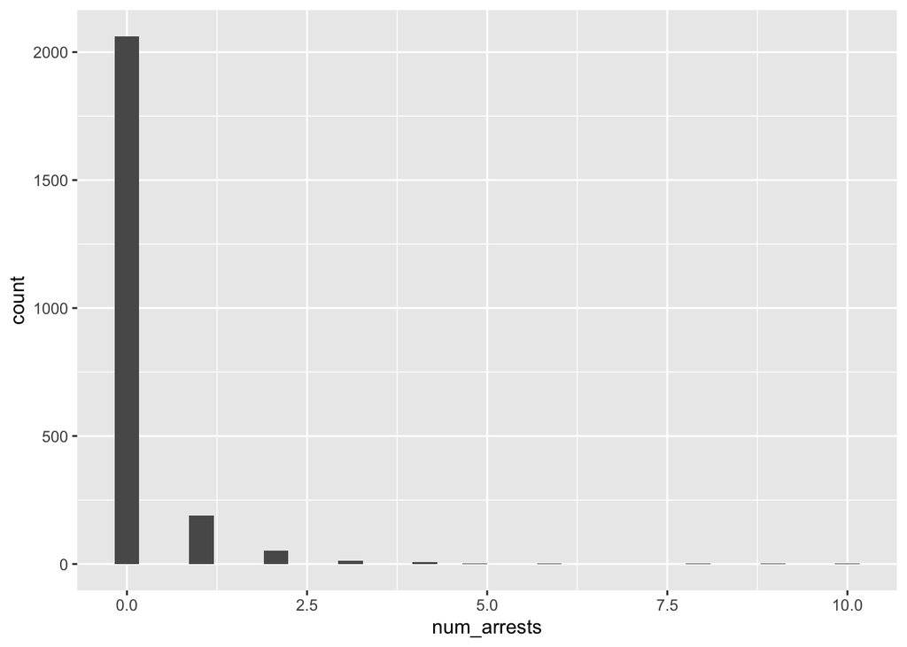

```r
arrest_hist <- ggplot(census2020) +
  geom_histogram(aes(x = num_arrests),
                 bins = 30)

arrest_hist
```

Total Arrests Histogram

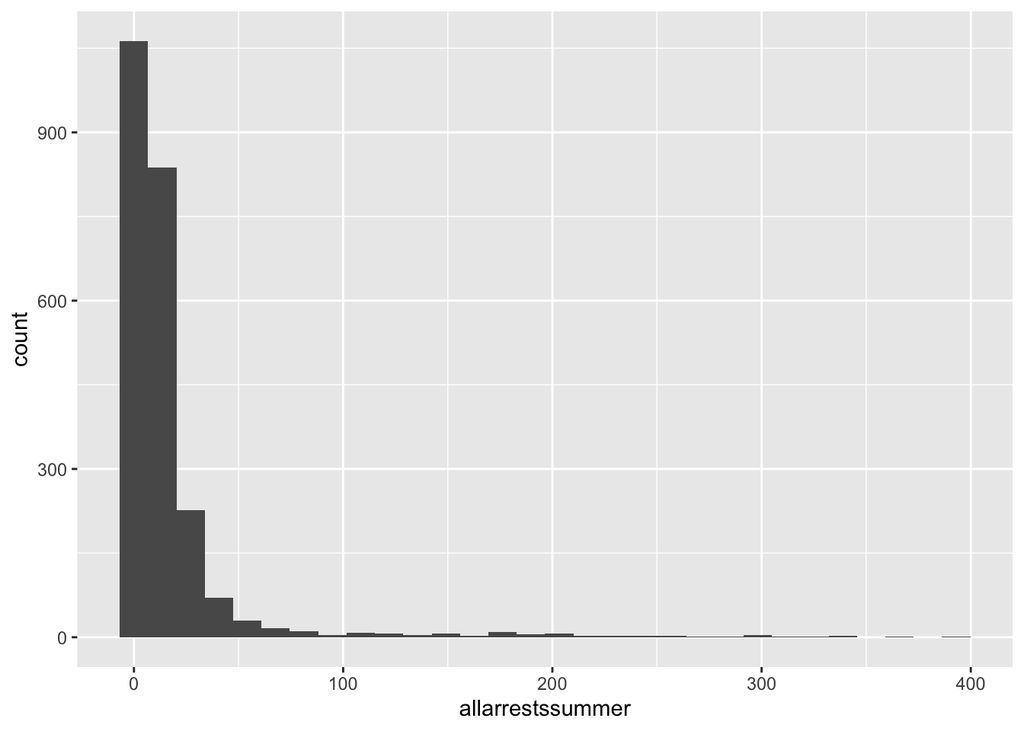

```r
totalarrest_hist <- ggplot(census2020) +
  geom_histogram(aes(x = allarrestssummer),
                 bins = 30)

totalarrest_hist
```

Table Comparing Arrests for Everything and Resisting Arrest

```r
cont_summary <- tibble(
  Variable = c("Median resisting arrests arrests per tract",
               "Median total arrests per tract"),
  `Sample mean` = c(arrest_t_test$estimate,
                    totalarrest_t_test$estimate),
  `Population mean (95% confidence) - low` =
    c(arrest_t_test$conf.int[1],
      totalarrest_t_test$conf.int[1]),
  `Population mean (95% confidence) - high` =
    c(arrest_t_test$conf.int[2],
      totalarrest_t_test$conf.int[2]),
  Median = c(arrest_quartiles[3],
             totalarrest_quartiles[3]),
  `Interquartile range` = c(arrest_quartiles[4] - arrest_quartiles[2],
                            totalarrest_quartiles[4] - totalarrest_quartiles[2]),
  `Standard deviation` = c(arrest_dev,
                         totalarrest_dev))
kable(cont_summary, digits = 0)
```

| Variable | Sample mean | Population mean (95% confidence) - low | Population mean (95% confidence) - high | Median | Interquartile range | Standard deviation |
| --- | --- | --- | --- | --- | --- | --- |
| Median resisting arrests arrests per tract | 0 | 0 | 0 | 0 | 0 | 1 |
| Median total arrests per tract | 17 | 15 | 18 | 7 | 13 | 36 |

## Libraries in NYC

```r
libr_t_test <- t.test(census2020$num_library)

totallibr_t_test <-t.test(census2020$num_library)
```

```r
libr_quartiles <- quantile(census2020$num_library, na.rm = TRUE)
totallibrary_quartiles <- quantile(census2020$num_library, na.rm = TRUE)
```

```r
libr_dev <- sd(census2020$num_library, na.rm = TRUE)
totallibr_dev<- sd(census2020$num_library, na.rm = TRUE)
```

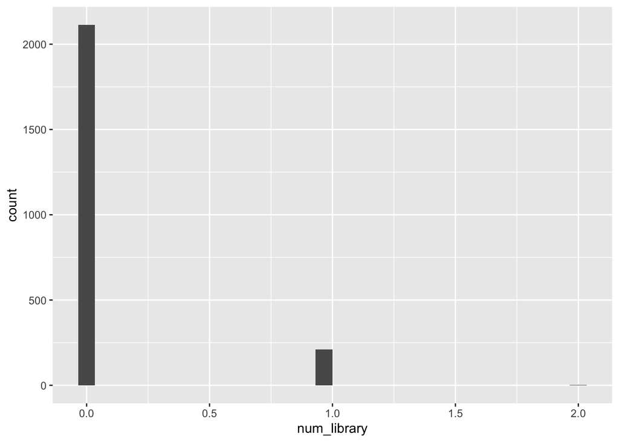

```r
libr_hist <- ggplot(census2020) +
  geom_histogram(aes(x = num_library),
                 bins = 30)

libr_hist
```

## Parks in NYC

```r
parks_t_test <- t.test(census2020$num_parks)

totalparks_t_test <-t.test(census2020$num_parks)
```

```r
parks_quartiles <- quantile(census2020$num_parks, na.rm = TRUE)
totalparks_quartiles <- quantile(census2020$num_parks, na.rm = TRUE)
```

```r
parks_dev <- sd(census2020$num_parks, na.rm = TRUE)
totalparks_dev<- sd(census2020$num_parks, na.rm = TRUE)
```

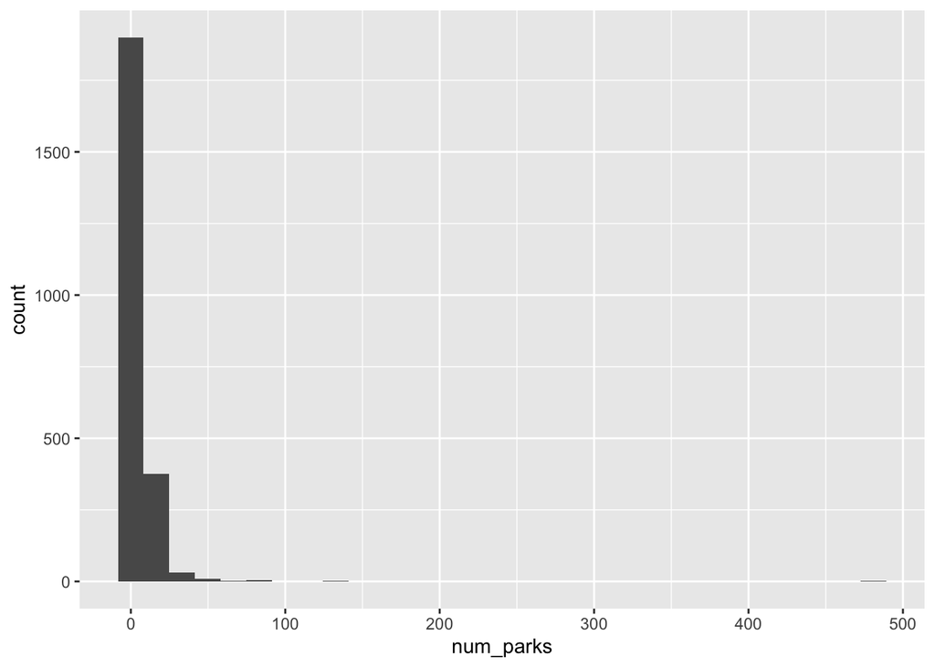

```r
parks_hist <- ggplot(census2020) +
  geom_histogram(aes(x = num_parks),
                 bins = 30)

parks_hist
```

## Subway Stations in NYC

```r
subway_t_test <- t.test(census2020$num_subway)

totalsubway_t_test <-t.test(census2020$num_subway)
```

```r
subway_quartiles <- quantile(census2020$num_subway, na.rm = TRUE)
totalsubway_quartiles <- quantile(census2020$num_subway, na.rm = TRUE)
```

```r
subway_dev <- sd(census2020$num_subway, na.rm = TRUE)
totalsubway_dev<- sd(census2020$num_subway, na.rm = TRUE)
```

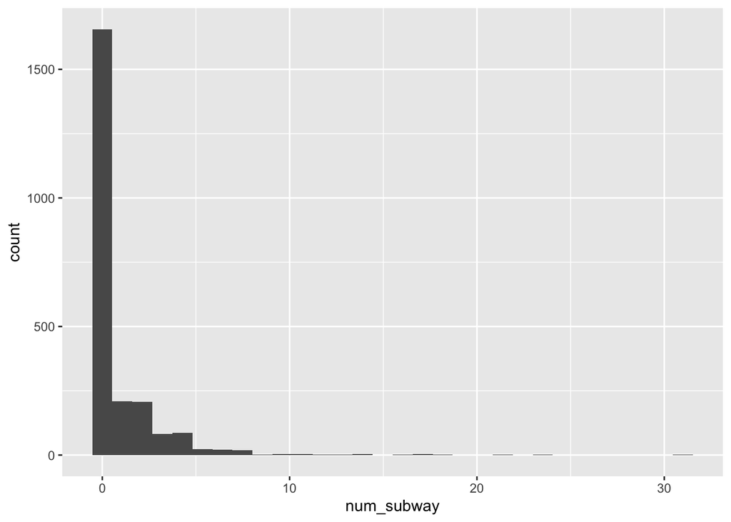

```r
subway_hist <- ggplot(census2020) +
  geom_histogram(aes(x = num_subway),
                 bins = 30)

subway_hist
```

# Categorical Data- Assignment 2

```r
pct_Queens<- t.test(arrestdata$arrest_boro == "Q")
pct_Brooklyn <-t.test(arrestdata$arrest_boro == "K")
pct_StatenIsland <-t.test(arrestdata$arrest_boro == "S")
pct_Manhattan <-t.test(arrestdata$arrest_boro == "M")
pct_Bronx <-t.test(arrestdata$arrest_boro == "B")
```

```r
PCT_summary_arrests <- tibble(`Percent of Protest Arrests in Each NYC Borough, Summer 2020` =
                            c("Bronx","Brooklyn",
                                "Queens","Manhattan", "Staten Island"),
                            `Sample proportion` =
                              c(pct_Bronx$estimate * 100,
                                pct_Brooklyn$estimate *100,
                                pct_Queens$estimate *100,
                                pct_Manhattan$estimate *100,
                                pct_StatenIsland$estimate *100),
                            `95-percent confidence - low` =
                              c(pct_Bronx$conf.int[1] * 100,
                                pct_Brooklyn$conf.int[1] * 100,
                                pct_Queens$conf.int[1] *100,
                            pct_Manhattan$conf.int[1] *100,
                            pct_StatenIsland$conf.int[1] *100),

                            `95-percent confidence - high` =
                              c(pct_Bronx$conf.int[2] * 100,
                                pct_Brooklyn$conf.int[2] * 100,
                                pct_Queens$conf.int[2]*100,
                                pct_Manhattan$conf.int[2]*100,
                                pct_StatenIsland$conf.int[2]*100))

kable(PCT_summary_arrests, digits = 0)
```

| Percent of Protest Arrests in Each NYC Borough, Summer 2020 | Sample proportion | 95-percent confidence - low | 95-percent confidence - high |
| --- | --- | --- | --- |
| Bronx | 18 | 15 | 22 |
| Brooklyn | 34 | 29 | 39 |
| Queens | 13 | 10 | 17 |
| Manhattan | 32 | 27 | 36 |
| Staten Island | 3 | 1 | 4 |

[figure not shown]

```r
ggplot(PCT_summary_arrests) +
  geom_bar(aes(x = `Percent of Protest Arrests in Each NYC Borough, Summer 2020`,
               y = `Sample proportion`),
           stat = "identity") +
  geom_errorbar(aes(x = `Percent of Protest Arrests in Each NYC Borough, Summer 2020`,
               y = `Sample proportion`,
               ymin = `95-percent confidence - low`,
               ymax = `95-percent confidence - high`),
           stat = "identity") +
  scale_y_continuous(name = "Percent of total protest arrests",
                     breaks = c(0, 20, 40, 60, 80),
                     labels = c("0", "10%", "20%", "30%", "40%")) +
  theme_bw()
```

# Bivariate Analysis - Assignment 3

Our dependent variable is the number of arrests made per census tract in New York City for “Resisting Arrest” in Summer 2020. Our independent variables are total number of arrests in the census tract for the same time period, population, number of parks, number of subway stations, and presence of a library or POPS.

## Correlations and Regressions (Continuous Variables)

### Total Number of Arrests

```r
cor.test(~ census2020$num_arrests + census2020$allarrestssummer, census2020 = census2020)
```

```
##
##  Pearson's product-moment correlation
##
## data:  census2020$num_arrests and census2020$allarrestssummer
## t = 13.551, df = 2325, p-value < 2.2e-16
## alternative hypothesis: true correlation is not equal to 0
## 95 percent confidence interval:
##  0.2324756 0.3078041
## sample estimates:
##       cor
## 0.2705539
```

Tracts with a higher number of arrests overall are associated with a higher number of arrests for resisting arrest. The correlation is .27 (and the 95% confidence interval does not cover 0 + p-value is less than .05)

### Population

```r
cor.test(~ census2020$num_arrests + census2020$pop, census2020 = census2020)
```

```
##
##  Pearson's product-moment correlation
##
## data:  census2020$num_arrests and census2020$pop
## t = 5.2206, df = 2325, p-value = 1.942e-07
## alternative hypothesis: true correlation is not equal to 0
## 95 percent confidence interval:
##  0.0673015 0.1476296
## sample estimates:
##       cor
## 0.1076412
```

Tracts with a higher population are associated with a higher number of arrests for resisting arrest.

The magnitude of the relationship is a correlation of .1 and the significance is a 95% confidence interval between .06 and .14.

### Number of Parks

```r
cor.test(~ census2020$num_arrests + census2020$num_parks, census2020 = census2020)
```

```
##
##  Pearson's product-moment correlation
##
## data:  census2020$num_arrests and census2020$num_parks
## t = 1.4703, df = 2325, p-value = 0.1416
## alternative hypothesis: true correlation is not equal to 0
## 95 percent confidence interval:
##  -0.01016790  0.07102496
## sample estimates:
##        cor
## 0.03047881
```

Tracts with a higher numbers of parks are associated with a higher number of arrests for resisting arrest–however the confidence interval includes 0, which means the correlation is not proven.

### Number of Subway Stations

```r
cor.test(~ census2020$num_arrests + census2020$num_subway, census2020 = census2020)
```

```
##
##  Pearson's product-moment correlation
##
## data:  census2020$num_arrests and census2020$num_subway
## t = 16.205, df = 2325, p-value < 2.2e-16
## alternative hypothesis: true correlation is not equal to 0
## 95 percent confidence interval:
##  0.2815841 0.3546168
## sample estimates:
##       cor
## 0.3185731
```

Tracts with a higher numbers of subways stations are associated with a higher number of arrests for resisting arrest. The correlation is .32 (and the confidence interval/p-value allow for confidence in this correlation.)

### Number of Libraries

```r
cor.test(~ census2020$num_arrests + census2020$num_library, census2020 = census2020)
```

```
##
##  Pearson's product-moment correlation
##
## data:  census2020$num_arrests and census2020$num_library
## t = 1.5473, df = 2325, p-value = 0.1219
## alternative hypothesis: true correlation is not equal to 0
## 95 percent confidence interval:
##  -0.008572328  0.072612447
## sample estimates:
##        cor
## 0.03207296
```

Tracts with a higher numbers of libraries are associated with a higher number of arrests for resisting arrest. However, the p-value and confidence interval show that this correlation is not proven.

### Number of Wifi Hotspots

```r
cor.test(~ census2020$num_arrests + census2020$num_wifi, census2020 = census2020)
```

```
##
##  Pearson's product-moment correlation
##
## data:  census2020$num_arrests and census2020$num_wifi
## t = 9.9513, df = 2325, p-value < 2.2e-16
## alternative hypothesis: true correlation is not equal to 0
## 95 percent confidence interval:
##  0.1628244 0.2407779
## sample estimates:
##       cor
## 0.2021213
```

### Number of Museums

```r
cor.test(~ census2020$num_arrests + census2020$num_museum, census2020 = census2020)
```

```
##
##  Pearson's product-moment correlation
##
## data:  census2020$num_arrests and census2020$num_museum
## t = 4.1215, df = 2325, p-value = 3.896e-05
## alternative hypothesis: true correlation is not equal to 0
## 95 percent confidence interval:
##  0.0446861 0.1253658
## sample estimates:
##        cor
## 0.08516558
```

### Number of Historic Buildings

```r
cor.test(~ census2020$num_arrests + census2020$num_historic, census2020 = census2020)
```

```
##
##  Pearson's product-moment correlation
##
## data:  census2020$num_arrests and census2020$num_historic
## t = 4.8904, df = 2325, p-value = 1.075e-06
## alternative hypothesis: true correlation is not equal to 0
## 95 percent confidence interval:
##  0.06051816 0.14096031
## sample estimates:
##       cor
## 0.1009041
```

## Difference in means (Categorical Variables)

### Presence of a POP

```r
census2020 <- census2020 %>%
  mutate(POPS_true = case_when(census2020$num_POPs == 0 ~ "False",
                               census2020$num_POPs== 1 ~ "True",
                               census2020$num_POPs== 2 ~ "True",
                               census2020$num_POPs== 3 ~ "True",
                               census2020$num_POPs== 4 ~ "True",
                               census2020$num_POPs== 5 ~ "True",
                               census2020$num_POPs== 6 ~ "True",
                               census2020$num_POPs== 7 ~ "True",
                               census2020$num_POPs== 8 ~ "True",
                               census2020$num_POPs== 9 ~ "True",
                               census2020$num_POPs== 10 ~ "True",
                               census2020$num_POPs== 11 ~ "True",
                               census2020$num_POPs== 12 ~ "True",
                               census2020$num_POPs== 13 ~ "True",
                               census2020$num_POPs== 14 ~ "True"))
t.test(census2020$num_arrests ~ census2020$POPS_true, census2020)
```

```
##
##  Welch Two Sample t-test
##
## data:  census2020$num_arrests by census2020$POPS_true
## t = -2.6436, df = 133.75, p-value = 0.009182
## alternative hypothesis: true difference in means is not equal to 0
## 95 percent confidence interval:
##  -0.60536258 -0.08720978
## sample estimates:
## mean in group False  mean in group True
##           0.1499544           0.4962406
```

The p value is less than .05 and confidence interval stays below zero, meaning there is a relationship between presence of a POP and Resisting Arrest charges.

The magnitude of the relationship is a difference in mean number of Resisting Arrests in tracts with a POP. In Tracts with a POP the mean Resisting Arrests number was .496 and in tracts without the mean was .150 representing a difference of .347. The significance is a 95% confidence interval between -.6 and -.08.

### Presence of a Library

```r
census2020 <- census2020 %>%
  mutate(library_true = case_when(census2020$num_library == 0 ~ "False",
                               census2020$num_library== 1 ~ "True",
                               census2020$num_library== 2 ~ "True"))

t.test(census2020$num_arrests ~ census2020$library_true, census2020)
```

```
##
##  Welch Two Sample t-test
##
## data:  census2020$num_arrests by census2020$library_true
## t = -1.6383, df = 256.41, p-value = 0.1026
## alternative hypothesis: true difference in means is not equal to 0
## 95 percent confidence interval:
##  -0.15754108  0.01445297
## sample estimates:
## mean in group False  mean in group True
##           0.1631977           0.2347418
```

The p value is over 0.05 and the confidence interval includes 0, meaning there is little to no correlation between the presence of libraries and Resisting Arrest charges.

# Multivariate Regression- Assignment 4:

## Multivariate Calculations

```r
full_model <- lm(census2020$num_arrests ~ census2020$allarrestssummer + census2020$num_parks + census2020$pop + census2020$num_subway + census2020$POPS_true + census2020$library_true, census2020)

summary(full_model)
```

```
##
## Call:
## lm(formula = census2020$num_arrests ~ census2020$allarrestssummer +
##     census2020$num_parks + census2020$pop + census2020$num_subway +
##     census2020$POPS_true + census2020$library_true, data = census2020)
##
## Residuals:
##     Min      1Q  Median      3Q     Max
## -2.0505 -0.1418 -0.0637 -0.0367  8.2220
##
## Coefficients:
##                               Estimate Std. Error t value Pr(>|t|)
## (Intercept)                  7.482e-03  2.492e-02   0.300    0.764
## census2020$allarrestssummer  3.662e-03  3.309e-04  11.064   <2e-16 ***
## census2020$num_parks         5.852e-04  9.120e-04   0.642    0.521
## census2020$pop               7.738e-06  5.875e-06   1.317    0.188
## census2020$num_subway        8.350e-02  6.348e-03  13.153   <2e-16 ***
## census2020$POPS_trueTrue     2.013e-03  5.461e-02   0.037    0.971
## census2020$library_trueTrue -5.063e-03  4.068e-02  -0.124    0.901
## ---
## Signif. codes:  0 '***' 0.001 '**' 0.01 '*' 0.05 '.' 0.1 ' ' 1
##
## Residual standard error: 0.5598 on 2320 degrees of freedom
## Multiple R-squared:  0.1505, Adjusted R-squared:  0.1483
## F-statistic: 68.49 on 6 and 2320 DF,  p-value: < 2.2e-16
```

```r
full_model2 <- lm(census2020$num_arrests ~ census2020$num_parks + census2020$pop + census2020$num_subway + census2020$POPS_true + census2020$library_true, census2020)

summary(full_model2)
```

```
##
## Call:
## lm(formula = census2020$num_arrests ~ census2020$num_parks +
##     census2020$pop + census2020$num_subway + census2020$POPS_true +
##     census2020$library_true, data = census2020)
##
## Residuals:
##     Min      1Q  Median      3Q     Max
## -2.1962 -0.1552 -0.0892 -0.0569  8.4304
##
## Coefficients:
##                              Estimate Std. Error t value Pr(>|t|)
## (Intercept)                 1.851e-02  2.554e-02   0.725  0.46864
## census2020$num_parks        9.427e-04  9.349e-04   1.008  0.31340
## census2020$pop              1.832e-05  5.946e-06   3.081  0.00209 **
## census2020$num_subway       9.254e-02  6.458e-03  14.330  < 2e-16 ***
## census2020$POPS_trueTrue    1.094e-02  5.601e-02   0.195  0.84519
## census2020$library_trueTrue 5.892e-07  4.173e-02   0.000  0.99999
## ---
## Signif. codes:  0 '***' 0.001 '**' 0.01 '*' 0.05 '.' 0.1 ' ' 1
##
## Residual standard error: 0.5743 on 2321 degrees of freedom
## Multiple R-squared:  0.1057, Adjusted R-squared:  0.1037
## F-statistic: 54.84 on 5 and 2321 DF,  p-value: < 2.2e-16
```

### Putting in new variables (wifi, museums, historic buildings)

```r
full_model3 <- lm(census2020$num_arrests ~ census2020$num_parks + census2020$pop + census2020$num_subway + census2020$POPS_true + census2020$library_true + census2020$num_wifi +  census2020$num_museum + census2020$num_historic,census2020)

summary(full_model3)
```

```
##
## Call:
## lm(formula = census2020$num_arrests ~ census2020$num_parks +
##     census2020$pop + census2020$num_subway + census2020$POPS_true +
##     census2020$library_true + census2020$num_wifi + census2020$num_museum +
##     census2020$num_historic, data = census2020)
##
## Residuals:
##     Min      1Q  Median      3Q     Max
## -2.3390 -0.1561 -0.0821 -0.0535  8.4472
##
## Coefficients:
##                               Estimate Std. Error t value Pr(>|t|)
## (Intercept)                  2.123e-02  2.555e-02   0.831   0.4061
## census2020$num_parks         7.974e-04  9.494e-04   0.840   0.4011
## census2020$pop               1.481e-05  6.047e-06   2.449   0.0144 *
## census2020$num_subway        8.623e-02  7.030e-03  12.266   <2e-16 ***
## census2020$POPS_trueTrue    -1.562e-02  5.900e-02  -0.265   0.7913
## census2020$library_trueTrue -9.766e-03  4.201e-02  -0.232   0.8162
## census2020$num_wifi          8.573e-03  4.460e-03   1.922   0.0547 .
## census2020$num_museum       -1.649e-02  4.022e-02  -0.410   0.6820
## census2020$num_historic      4.790e-04  1.955e-04   2.450   0.0143 *
## ---
## Signif. codes:  0 '***' 0.001 '**' 0.01 '*' 0.05 '.' 0.1 ' ' 1
##
## Residual standard error: 0.5734 on 2318 degrees of freedom
## Multiple R-squared:  0.1097, Adjusted R-squared:  0.1067
## F-statistic: 35.72 on 8 and 2318 DF,  p-value: < 2.2e-16
```

## Summary of Analysis

The greatest correlation with a p-value under .05 and a 95% confidence interval that does not include zero is between resisting arrest charges and another continuous variable is the presence of subway stations at .32. The more subway stations in a census tract, the more arrests for resisting arrest. Other continuous variables that showed correlation within 95% confidence are number of total arrests (the more total arrests, the more charges for resisting arrest) and total population (more population in a tract, more charges for resisting arrest). The presence of parks or libraries did not have significant correlation on the number of resisting arrest charges.

For categorical variables, the presence of at least one POP showed correlation with a higher number of resisting arrest charges and the presence of at least one Library did not show correlation.

The multivariate analysis shows that when controlling for all other variables, only the total number of arrests and number of subway stations in a census tract have an impact on the number of resisting arrest charges (because their p-values are less than .05). Subway stations, in our bivariate analysis, already had the strongest correlation and total number of arrests was close behind. However, the difference between one and two subway stations in a neighborhood is much bigger than the difference between one or two arrests, so understanding the context of the variables is important.

Our R-Squared value for this regression is .15, suggesting that this model explains about 15% of Resisting Arrest charges in NYC in Summer 2020.

# Assignment 5 - Transformations

## Adding an arrest per capita columns

```r
census2020 <- census2020 %>%
  mutate(arrest_percapita = as.numeric(num_arrests/pop))

census2020 <- census2020 %>%
  mutate(totalarrest_percapita = as.numeric(allarrestssummer/pop))
```

## Centering the Data

```r
centered_data <- census2020 %>%
  mutate(num_subway = num_subway - mean(num_subway, na.rm=TRUE),
         pop = pop - mean(pop , na.rm=TRUE),
         num_historic  = num_historic - mean(num_historic, na.rm=TRUE))


centered_model <- lm(census2020$num_arrests~ census2020$num_subway + census2020$pop + census2020$num_parks + census2020$num_historic + census2020$POPS_true + census2020$num_wifi + census2020$num_museum , centered_data)

export_summs(full_model3, centered_model,
             error_format = "(p = {p.value})",
             error_pos = "same",
             model.names = c("Initial", "Centered"))
```

|  | Initial | Centered |
| --- | --- | --- |
| (Intercept) | 0.02 (p = 0.41) | 0.02 (p = 0.41) |
| census2020$num_parks | 0.00 (p = 0.40) | 0.00 (p = 0.40) |
| census2020$pop | 0.00 * (p = 0.01) | 0.00 * (p = 0.01) |
| census2020$num_subway | 0.09 *** (p = 0.00) | 0.09 *** (p = 0.00) |
| census2020$POPS_trueTrue | -0.02 (p = 0.79) | -0.02 (p = 0.80) |
| census2020$library_trueTrue | -0.01 (p = 0.82) |  |
| census2020$num_wifi | 0.01 (p = 0.05) | 0.01 (p = 0.06) |
| census2020$num_museum | -0.02 (p = 0.68) | -0.02 (p = 0.68) |
| census2020$num_historic | 0.00 * (p = 0.01) | 0.00 * (p = 0.01) |
| N | 2327 | 2327 |
| R2 | 0.11 | 0.11 |
| *** p < 0.001; ** p < 0.01; * p < 0.05. |  |  |

## Scaling the population , wifi, and historic buildings

```r
data_scaled <- census2020 %>%
  mutate(pop = pop / 1000, num_wifi = num_wifi/10, num_historic = num_historic/100)

centered_scaled <-centered_data %>%
  mutate(pop = pop / 1000, num_wifi = num_wifi/10, num_historic = num_historic/100)

model_scaled <- lm(census2020$num_arrests~ census2020$num_parks+ census2020$num_subway + census2020$pop + census2020$num_historic + census2020$num_wifi  + census2020$num_museum + census2020$POPS_true , data_scaled)

modelcentered_scaled <- lm(census2020$num_arrests~ census2020$num_parks + census2020$num_subway + census2020$pop + census2020$num_historic + census2020$num_wifi  + census2020$num_museum + census2020$POPS_true, centered_scaled)

export_summs(full_model3, centered_model, model_scaled, modelcentered_scaled,
             error_format = "(p = {p.value})",
             error_pos = "same",
             model.names = c("Initial",
                             "Centered",
                             "Initial Scaled",
                             "Centered Scaled"))
```

|  | Initial | Centered | Initial Scaled | Centered Scaled |
| --- | --- | --- | --- | --- |
| (Intercept) | 0.02 (p = 0.41) | 0.02 (p = 0.41) | 0.02 (p = 0.41) | 0.02 (p = 0.41) |
| census2020$num_parks | 0.00 (p = 0.40) | 0.00 (p = 0.40) | 0.00 (p = 0.40) | 0.00 (p = 0.40) |
| census2020$pop | 0.00 * (p = 0.01) | 0.00 * (p = 0.01) | 0.00 * (p = 0.01) | 0.00 * (p = 0.01) |
| census2020$num_subway | 0.09 *** (p = 0.00) | 0.09 *** (p = 0.00) | 0.09 *** (p = 0.00) | 0.09 *** (p = 0.00) |
| census2020$POPS_trueTrue | -0.02 (p = 0.79) | -0.02 (p = 0.80) | -0.02 (p = 0.80) | -0.02 (p = 0.80) |
| census2020$library_trueTrue | -0.01 (p = 0.82) |  |  |  |
| census2020$num_wifi | 0.01 (p = 0.05) | 0.01 (p = 0.06) | 0.01 (p = 0.06) | 0.01 (p = 0.06) |
| census2020$num_museum | -0.02 (p = 0.68) | -0.02 (p = 0.68) | -0.02 (p = 0.68) | -0.02 (p = 0.68) |
| census2020$num_historic | 0.00 * (p = 0.01) | 0.00 * (p = 0.01) | 0.00 * (p = 0.01) | 0.00 * (p = 0.01) |
| N | 2327 | 2327 | 2327 | 2327 |
| R2 | 0.11 | 0.11 | 0.11 | 0.11 |
| *** p < 0.001; ** p < 0.01; * p < 0.05. |  |  |  |  |

## Comparing Arrests Overall

```r
total_model <- lm(census2020$allarrestssummer ~ census2020$num_parks + census2020$pop + census2020$num_subway + census2020$POPS_true + census2020$library_true + census2020$num_wifi +  census2020$num_museum + census2020$num_historic,census2020)

total_centered_model <- lm(census2020$allarrestssummer ~ census2020$num_subway + census2020$pop + census2020$num_parks + census2020$num_historic + census2020$num_wifi + census2020$num_museum + census2020$POPS_true, centered_data)

total_model_scaled <- lm(census2020$allarrestssummer ~ census2020$num_parks+ census2020$num_subway + census2020$pop + census2020$num_historic + census2020$num_wifi  + census2020$num_museum  , data_scaled)

totalmodelcentered_scaled <- lm(census2020$allarrestssummer ~ census2020$num_parks+ census2020$num_subway + census2020$pop + census2020$num_historic + census2020$num_wifi  + census2020$num_museum  , centered_scaled)

export_summs(total_model, total_centered_model, total_model_scaled, totalmodelcentered_scaled,
             error_format = "(p = {p.value})",
             error_pos = "same",
             model.names = c("ALL ARRESTS \nInitial",
                             "ALL ARRESTS \nCentered",
                             "ALL ARRESTS \nInitial Scaled",
                             "ALL ARRESTS \nCentered Scaled"))
```

|  | ALL ARRESTS Initial | ALL ARRESTS Centered | ALL ARRESTS Initial Scaled | ALL ARRESTS Centered Scaled |
| --- | --- | --- | --- | --- |
| (Intercept) | 3.21 * (p = 0.04) | 3.23 * (p = 0.04) | 3.21 * (p = 0.04) | 3.21 * (p = 0.04) |
| census2020$num_parks | 0.09 (p = 0.14) | 0.09 (p = 0.14) | 0.09 (p = 0.14) | 0.09 (p = 0.14) |
| census2020$pop | 0.00 *** (p = 0.00) | 0.00 *** (p = 0.00) | 0.00 *** (p = 0.00) | 0.00 *** (p = 0.00) |
| census2020$num_subway | 2.15 *** (p = 0.00) | 2.15 *** (p = 0.00) | 2.16 *** (p = 0.00) | 2.16 *** (p = 0.00) |
| census2020$POPS_trueTrue | 0.68 (p = 0.85) | 0.64 (p = 0.86) |  |  |
| census2020$library_trueTrue | 0.75 (p = 0.77) |  |  |  |
| census2020$num_wifi | 0.58 * (p = 0.03) | 0.59 * (p = 0.03) | 0.60 * (p = 0.02) | 0.60 * (p = 0.02) |
| census2020$num_museum | -1.13 (p = 0.65) | -1.10 (p = 0.65) | -1.03 (p = 0.67) | -1.03 (p = 0.67) |
| census2020$num_historic | 0.01 (p = 0.66) | 0.01 (p = 0.67) | 0.01 (p = 0.67) | 0.01 (p = 0.67) |
| N | 2327 | 2327 | 2327 | 2327 |
| R2 | 0.06 | 0.06 | 0.06 | 0.06 |
| *** p < 0.001; ** p < 0.01; * p < 0.05. |  |  |  |  |

## Interpreting the Data

The transformations that we tried were first means centering subway, population, and historic districts. Second, we tried scaling population to steps of 1,000 and wi-fi by steps of ten and historic districts by steps of 100. Third, we tried a combination of these transformations (means centered AND scaled). In all three analyses the outputs remained almost identical. One reason for the lack of change could be that many census tracts have an average number of subway stations, population (which makes sense because the Census Bureau tries to standardize this), and historic buildings. While this does make sense for population, it makes less sense for subway stations and historic districts which do seem to really vary.The impact of the independent variables on the dependent variable is pretty small so it is hard to see differences with only two decimal places. We tried out modifying the arrests to be per capita, with the plan to scale this up by 1000 and see if making the numbers larger allowed us to see more variation. However, we ran into an issue because the new column created NA values which then made the regression models not work.

# Assignment 6: Interactions

```r
coeff_names_interaction <- c("Constant" = "(Intercept)",
                 "Number of Wifi Spots" = "census2020$num_wifi",
                 "Number of Historic Sites" = "census2020$num_historic",
                 "Number of Parks" = "census2020$num_parks",
                 "Number of Subways" = "census2020$num_subway",
                 "Number of Museums" = "census2020$num_museum",
                 "Resisting Arrests Charges" = "census2020$num_arrests",
                 "Population in 2020" = "census2020$pop",
                 "Has a POPS" = "census2020$POPS_trueTrue")


interaction_model <- lm(census2020$num_arrests ~ census2020$num_subway + census2020$pop + census2020$num_parks + census2020$num_historic + census2020$num_wifi + census2020$num_museum + census2020$POPS_true + census2020$num_subway*census2020$POPS_true,  centered_data)

export_summs(centered_model, interaction_model,
             error_format = "(p = {p.value})",
             error_pos = "same",
             model.names = c("Centered Data",
                             "Centered Data with Interactions"))
```

|  | Centered Data | Centered Data with Interactions |
| --- | --- | --- |
| (Intercept) | 0.02 (p = 0.41) | 0.02 (p = 0.33) |
| census2020$num_subway | 0.09 *** (p = 0.00) | 0.05 *** (p = 0.00) |
| census2020$pop | 0.00 * (p = 0.01) | 0.00 ** (p = 0.00) |
| census2020$num_parks | 0.00 (p = 0.40) | 0.00 (p = 0.22) |
| census2020$num_historic | 0.00 * (p = 0.01) | 0.00 ** (p = 0.00) |
| census2020$POPS_trueTrue | -0.02 (p = 0.80) | -0.18 ** (p = 0.01) |
| census2020$num_wifi | 0.01 (p = 0.06) | 0.01 (p = 0.06) |
| census2020$num_museum | -0.02 (p = 0.68) | -0.02 (p = 0.61) |
| census2020$num_subway:census2020$POPS_trueTrue |  | 0.07 *** (p = 0.00) |
| N | 2327 | 2327 |
| R2 | 0.11 | 0.12 |
| *** p < 0.001; ** p < 0.01; * p < 0.05. |  |  |

## Explanation

# References

Rafail, Patrick. “Protest in the City: Urban Spatial Restructuring and Dissent in New York, 1960–2006.” Urban Studies 55, no. 1 (January 2018): 244–60. https://doi.org/10.1177/0042098016661464.

Armed Conflict Location & Event Data Project (ACLED), The US Crisis Monitor, 2020 https://acleddata.com/acleddatanew/wp-content/uploads/2020/09/ACLED_USDataReview_Sum2020_SeptWebPDF_HiRes.pdf